# Assignment6

Han Siyue 17307110012

2019/11/5

## 某移动通讯客户流失预警分析案例

案例背景：目前在我国移动通讯行业基本呈现三足鼎立的局势，市场份额由中国移动、中国联通和中国电信三家运营商瓜分。客户流失问题非常严重，从近5年的统计数字来看，三家运营商的移动客户数增长缓慢，中国联通在2015年甚至出现了负增长。因此建立一套系统的客户流失预警体系已是燃眉之急。案例原文详见某移动通讯公司客户流失预警分析

本案例使用的数据来自国内某运营商，数据已经进行了清理，数据集中的变量包括：

【因变量】

是否流失：1=流失；0=非流失

【自变量】

- 在网时长（tenure）：客户从入网到截止数据提取日期时在网时间，单位：天
- 当月花费（expense）：客户在提取月份时的花费总额，单位：元
- 个体的度（degree）：和客户通话的总人数，去重之后的呼入与呼出贾总，单位： 人数
- 联系强度（tightness）：通话总时间除以总人数，单位：分钟/人
- 个体信息熵（entropy）：计算公式详见数据说明
- 个体度的变化（chgdegree）：（本月个体的度-上月个体的度）/上月个体的度
- 花费的变化（chgexpense）：（本月花费-上月花费）/上月花费

本案例学习目标：

- 拟合逻辑回归模型并给出标准化系数估计
- 进行外样本预测
- 学习绘制覆盖率-捕获率曲线

### 准备工作

清除工作环境，安装和加载一些需要的包。

```r
cat("\014"); rm(list=ls())  # 清除工作环境
```

```r
library(ggplot2)
library(nnet)
```

### 任务一

读入数据并检查是否有异常值存在，如果观测值超出均值加减3倍标准差的范围，则进行删除。分别用summary函数展示异常值处理之前与之后的数据。

```r
# read the original data
data_orig <- read.csv("sampledata.csv", fileEncoding = 'UTF-8')
pred_orig <- read.csv("preddata.csv", fileEncoding = 'UTF-8')
summary(data_orig)
```

```
##        ID            tenure          expense            degree
##  Min.   :    1   Min.   : 184.0   Min.   : -2.764   Min.   : -0.3713
##  1st Qu.:12099   1st Qu.: 537.2   1st Qu.: 98.211   1st Qu.: 30.2663
##  Median :24197   Median : 994.7   Median :135.927   Median : 54.0370
##  Mean   :24197   Mean   :1257.4   Mean   :161.079   Mean   : 66.6072
##  3rd Qu.:36295   3rd Qu.:1635.9   3rd Qu.:204.007   3rd Qu.: 89.7611
##  Max.   :48393   Max.   :4479.6   Max.   :511.055   Max.   :303.9827
##    tightness         entropy        chgexpense          chgdegree
##  Min.   :-2.355   Min.   :0.000   Min.   :-1.000000   Min.   :-0.99644
##  1st Qu.: 5.403   1st Qu.:2.371   1st Qu.:-0.076554   1st Qu.:-0.15790
##  Median : 8.021   Median :2.988   Median : 0.000000   Median : 0.00000
##  Mean   : 9.846   Mean   :2.928   Mean   : 0.007203   Mean   : 0.03693
##  3rd Qu.:11.941   3rd Qu.:3.558   3rd Qu.: 0.043241   3rd Qu.: 0.16667
##  Max.   :62.509   Max.   :5.346   Max.   : 2.665025   Max.   : 7.33333
##      churn
##  Min.   :0.00000
##  1st Qu.:0.00000
##  Median :0.00000
##  Mean   :0.01273
##  3rd Qu.:0.00000
##  Max.   :1.00000
```

```r
# initialize the reserved row as all-reserved
reserve <- 1
for (i in 2:8) {
  # take the i-th column as a vector
  col_vec <- data_orig[, i]
  # set the lower and upper bound for each column
  lower <- mean(col_vec) - 3 * sd(col_vec)
  upper <- mean(col_vec) + 3 * sd(col_vec)
  # reserve only rows which fall between two bounds
  reserve <- reserve & (lower <= col_vec & col_vec <= upper)
}
data_trim <- data_orig[reserve, ]
summary(data_trim)
```

```
##        ID            tenure          expense             degree
##  Min.   :    1   Min.   : 184.0   Min.   :  0.4047   Min.   :  0.699
##  1st Qu.:12952   1st Qu.: 524.8   1st Qu.: 97.4200   1st Qu.: 30.764
##  Median :24844   Median : 964.8   Median :133.3037   Median : 53.800
##  Mean   :24771   Mean   :1181.7   Mean   :156.3121   Mean   : 64.190
##  3rd Qu.:36629   3rd Qu.:1610.0   3rd Qu.:199.4546   3rd Qu.: 87.555
##  Max.   :48393   Max.   :4154.2   Max.   :429.7999   Max.   :214.091
##    tightness         entropy         chgexpense         chgdegree
##  Min.   :-2.355   Min.   :0.3493   Min.   :-0.81239   Min.   :-0.992063
##  1st Qu.: 5.435   1st Qu.:2.4039   1st Qu.:-0.08012   1st Qu.:-0.160239
##  Median : 8.002   Median :2.9865   Median : 0.00000   Median :-0.009615
##  Mean   : 9.282   Mean   :2.9347   Mean   :-0.01543   Mean   : 0.010670
##  3rd Qu.:11.695   3rd Qu.:3.5325   3rd Qu.: 0.03220   3rd Qu.: 0.155106
##  Max.   :31.280   Max.   :5.0324   Max.   : 0.82634   Max.   : 1.195122
##      churn
##  Min.   :0.00000
##  1st Qu.:0.00000
##  Median :0.00000
##  Mean   :0.01196
##  3rd Qu.:0.00000
##  Max.   :1.00000
```

### 任务二

先对自变量进行标准化，使得其均值为0，方差为1。然后拟合逻辑回归模型，给出标准化系数估计结果。

```r
# 标准化自变量
data_std <- cbind(data_trim[, 1], as.data.frame(scale(data_trim[, c(-1, -9)])), data_trim[, 9])
colnames(data_std)[1] <- "ID"
colnames(data_std)[9] <- "churn"
# 建立逻辑回归模型
logit_model <- glm(churn ~ tenure + expense + degree + tightness + entropy + chgdegree + chgexpense, family = binomial(link = "logit"), data = data_std)
summary(logit_model)
```

```
##
## Call:
## glm(formula = churn ~ tenure + expense + degree + tightness +
##     entropy + chgdegree + chgexpense, family = binomial(link = "logit"),
##     data = data_std)
##
## Deviance Residuals:
##     Min       1Q   Median       3Q      Max
## -0.7868  -0.1710  -0.1168  -0.0731   4.1285
##
## Coefficients:
##             Estimate Std. Error z value Pr(>|z|)
## (Intercept) -5.08344    0.07612 -66.783  < 2e-16 ***
## tenure      -0.27275    0.06301  -4.328 1.50e-05 ***
## expense     -0.24236    0.06046  -4.009 6.11e-05 ***
## degree      -0.85321    0.13716  -6.221 4.95e-10 ***
## tightness   -0.22492    0.04540  -4.954 7.27e-07 ***
## entropy     -0.17609    0.08320  -2.116  0.03431 *
## chgdegree   -0.36545    0.04528  -8.070 7.01e-16 ***
## chgexpense  -0.14662    0.04481  -3.272  0.00107 **
## ---
## Signif. codes:  0 '***' 0.001 '**' 0.01 '*' 0.05 '.' 0.1 ' ' 1
##
## (Dispersion parameter for binomial family taken to be 1)
##
##     Null deviance: 5647.9  on 43562  degrees of freedom
## Residual deviance: 5034.1  on 43555  degrees of freedom
## AIC: 5050.1
##
## Number of Fisher Scoring iterations: 8
```

### 任务三

将任务二中的参数估计结果应用到predata中，给出predata中每个用户预测的流失概率值，展示前6行的预测结果。

```r
# 对预测集做标准化处理
pred_std <- cbind(pred_orig[, 1], as.data.frame(scale(pred_orig[, c(-1, -9)])), pred_orig[, 9])
colnames(pred_std)[1] <- "ID"
colnames(pred_std)[9] <- "churn"
# 运用predict方程作出预测
pred_std$prob <- predict(logit_model, newdata = pred_std[, c(-1, -9)], type = "response")
head(pred_std$prob)
```

```
## [1] 0.0284708585 0.0049891320 0.0064184322 0.0006687436 0.0060906569
## [6] 0.0039056131
```

### 任务四

绘制覆盖率-捕获率曲线。逻辑回归的评价指标ROC曲线（或AUC值）我们已经非常熟悉了，那么什么是覆盖率-捕获率曲线呢？其实和ROC曲线差不多，只不过在业界比较常用。可以这样理解覆盖率-捕获率曲线：根据模型给出每个样本的预测流失概率值，按照预测值从高到低对样本进行排序，例如只覆盖前10%的样本，计算对应的真实流失的样本数占所有流失样本数的比例，记为捕获率，以此类推，可以覆盖不同比例的样本，就可以计算不同的覆盖率对应的捕获率，从而得到覆盖率捕获率曲线，如果在较低的覆盖率情况可以获得较高的捕获率，那么说明模型的精度比较高。因此在绘制的时候需要借助循环，计算不同的覆盖率下的捕获率是多少，最后进行曲线的绘制。

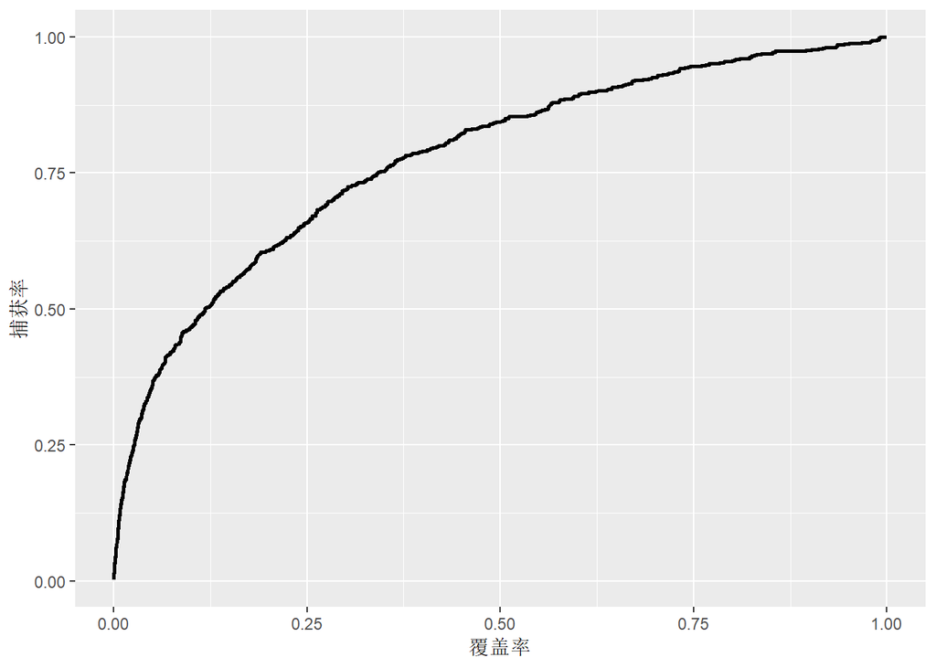

```r
# 提取捕获率和覆盖率信息
data <- pred_std[, c(9, 10)]
data <- data[order(-data$prob), ]
nrows <- nrow(data)
coverage <- (1:nrows)/nrows
capture <- data[, 1]
for (i in 2:nrows) {
  capture[i] <- capture[i-1] + capture[i]
}
capture <- capture / sum(data$churn)
data_plot <- cbind(as.data.frame(coverage), as.data.frame(capture))
# 绘制覆盖率-捕获率曲线
ggplot(data = data_plot) +
  geom_line(aes(coverage, capture), size = 1) +
  xlab("覆盖率") +
  ylab("捕获率")
```